# IODS course project

# Introduction to Open Data Science - Course Project

# About the project

```r
# This is a so-called "R chunk" where you can write R code.

date()
```

```
## [1] "Wed Dec 02 09:29:03 2020"
```

This is a good introduction to the course. I am really excited about this course and hope to learn alot as a start to my data science journey. I saw this coures on weboodi and was really interested.

my link: https://github.com/swachiye/IODS-project

# **Regession and Model Validation**

Author: Sheila Wachiye

Date: November 5 2020

# *Introduction*

**Regression**

Regression is a statistical method used to assess the relationship between a dependent variable and one and more independent variables. The dependent variable can be seen as response variable while the independent variables as explanatory variables.

**Exercise**

Regression analysis using RMarkdown include the following steps For this report, we will be using “learning2014”

View data using this link http://s3.amazonaws.com/assets.datacamp.com/production/course_2218/datasets/learning2014.txt)

**Load data**

Load data by assigning a name. In this case we use “lrn14”.

Use *read.table* function, to read the file in a table format and creates a data frame. The separator is a comma “,” and the file includes a header

```r
lrn14 <- read.table("http://s3.amazonaws.com/assets.datacamp.com/production/course_2218/datasets/learning2014.txt", sep=",", header=TRUE)
```

**Visualise data**

```r
# data structure using str()
# str() function in is used for compactly display the internal structure of the dataframe
str(lrn14)
```

```
## 'data.frame':    166 obs. of  7 variables:
##  $ gender  : Factor w/ 2 levels "F","M": 1 2 1 2 2 1 2 1 2 1 ...
##  $ age     : int  53 55 49 53 49 38 50 37 37 42 ...
##  $ attitude: num  3.7 3.1 2.5 3.5 3.7 3.8 3.5 2.9 3.8 2.1 ...
##  $ deep    : num  3.58 2.92 3.5 3.5 3.67 ...
##  $ stra    : num  3.38 2.75 3.62 3.12 3.62 ...
##  $ surf    : num  2.58 3.17 2.25 2.25 2.83 ...
##  $ points  : int  25 12 24 10 22 21 21 31 24 26 ...
```

```r
# It tells us about each variable one by ones below
```

```r
# data dimensions dim()
# This gives you the number of rows and columns in the data frame
dim(lrn14)
```

```
## [1] 166   7
```

Based on the above output, we have 166 observaions (rows) and 7 variables (columns)

```r
# Access the first top six rows in the data frame using head() and the six bottom using tail()
head(lrn14)
```

```
##   gender age attitude     deep  stra     surf points
## 1      F  53      3.7 3.583333 3.375 2.583333     25
## 2      M  55      3.1 2.916667 2.750 3.166667     12
## 3      F  49      2.5 3.500000 3.625 2.250000     24
## 4      M  53      3.5 3.500000 3.125 2.250000     10
## 5      M  49      3.7 3.666667 3.625 2.833333     22
## 6      F  38      3.8 4.750000 3.625 2.416667     21
```

```r
tail(lrn14)
```

```
##     gender age attitude     deep  stra     surf points
## 161      F  19      2.0 4.083333 3.375 2.833333     20
## 162      F  22      4.2 2.916667 1.750 3.166667     28
## 163      M  35      4.1 3.833333 3.000 2.750000     31
## 164      F  18      3.7 3.166667 2.625 3.416667     18
## 165      F  19      3.6 3.416667 2.625 3.000000     30
## 166      M  21      1.8 4.083333 3.375 2.666667     19
```

```r
# obtain the column names
colnames(lrn14)
```

```
## [1] "gender"   "age"      "attitude" "deep"     "stra"     "surf"
## [7] "points"
```

Create graphics using *ggplots function*.

Ggplot2 is an implementation of Leland Wilkinson’s Grammar of Graphics which is popula for data visualization.

```r
#Access the *gglot2* using library
library(ggplot2)
```

Plot Exams points against students attitude

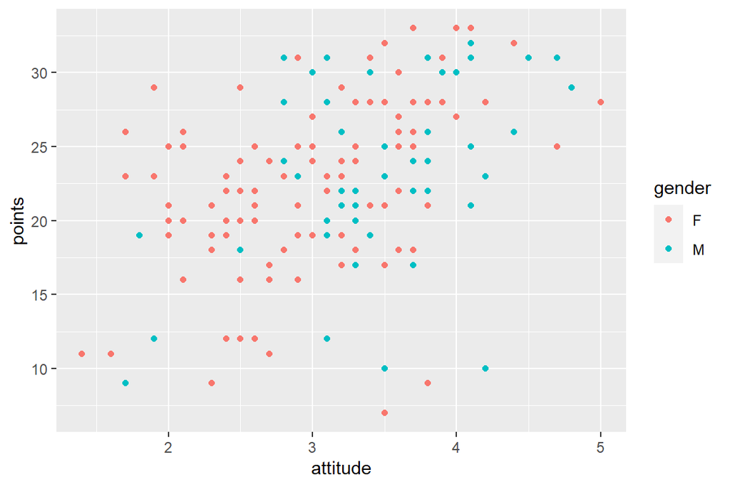

```r
# initialize plot with data and aesthetic mapping
# ighlight the distribution of the attitude based on gender, use *col(gender)*. This will assign different colors for each of the gender.
p1 <- ggplot(lrn14, aes(x = attitude, y = points, col= gender))

# define the visualization type (points)
p2 <- p1 + geom_point()

# draw the plot
p2
```